# Klasifikasi Logistic Regression, Naive Bayes, Decision Tree

#### Nama : Ryan Rachmad Hidayat

#### NIM : 162012133022

#### Mata Kuliah : Data Mining 1

#### Tugas Individu : Klasifikasi

## Informasi Singkat Dataset

### Pemasaran Bank

#### Abstrak:

Data tersebut terkait dengan kampanye pemasaran langsung (panggilan telepon) dari lembaga perbankan Portugis. Tujuan klasifikasi adalah untuk memprediksi apakah klien akan berlangganan deposito berjangka (variabel y).

#### Informasi Kumpulan Data:

Data tersebut terkait dengan kampanye pemasaran langsung dari lembaga perbankan Portugis. Kampanye pemasaran didasarkan pada panggilan telepon. Seringkali, lebih dari satu kontak ke klien yang sama diperlukan, untuk mengakses apakah produk (deposito berjangka bank) akan ('ya') atau tidak ('tidak') berlangganan.

### Informasi Atribut:

#### Data klien bank:

- Usia (angka)
- Pekerjaan : jenis pekerjaan (kategori: 'admin.', 'kerah biru', 'pengusaha', 'pembantu rumah tangga', 'manajemen', 'pensiun', 'wiraswasta', 'jasa', 'mahasiswa', ' teknisi', 'menganggur', 'tidak diketahui')
- Perkawinan : status perkawinan (kategoris: 'cerai', 'menikah', 'lajang', 'tidak diketahui' ; catatan: 'cerai' berarti cerai atau duda)
- Pendidikan (kategoris: 'basic.4y', 'basic.6y', 'basic.9y', 'high.school', 'buta huruf', 'professional.course', 'university.degree', 'unknown')
- Default: memiliki kredit default? (kategoris: 'tidak', 'ya', 'tidak diketahui')
- Perumahan: memiliki pinjaman perumahan? (kategoris: 'tidak', 'ya', 'tidak diketahui')
- Pinjaman: memiliki pinjaman pribadi? (kategoris: 'tidak', 'ya', 'tidak diketahui')

#### Terkait dengan kontak terakhir dari kampanye saat ini:

- Kontak: tipe komunikasi kontak (kategoris: 'seluler', 'telepon')
- Bulan: bulan kontak terakhir tahun ini (kategoris: 'jan', 'feb', 'mar', …, 'nov', 'des')
- Dayofweek: hari kontak terakhir dalam seminggu (kategoris: 'sen', 'sel', 'menikah', 'kami', 'jum')
- Durasi: durasi kontak terakhir, dalam detik (numerik). Penting catatan: atribut ini sangat mempengaruhi target keluaran (misalnya, jika durasi=0 lalu y='tidak'). Namun, durasinya tidak diketahui sebelum panggilan dilakukan. Juga, setelah akhir panggilan y jelas diketahui. Dengan demikian, input ini hanya boleh dimasukkan untuk tujuan benchmark dan harus dibuang jika tujuannya adalah untuk memiliki realistis model prediksi.

#### Atribut lainnya:

- Kampanye: jumlah kontak yang dilakukan selama kampanye ini dan untuk klien ini (numerik, termasuk kontak terakhir)
- Pdays: jumlah hari yang berlalu setelah klien terakhir dihubungi dari kampanye sebelumnya (angka; 999 berarti klien tidak dihubungi sebelumnya)
- Sebelumnya: jumlah kontak yang dilakukan sebelum kampanye ini dan untuk klien ini (numerik)
- Poutcome: hasil dari kampanye pemasaran sebelumnya (kategoris: 'gagal', 'tidak ada', 'berhasil')

#### Atribut konteks sosial dan ekonomi

- Emp.var.rate: tingkat variasi pekerjaan - indikator triwulanan (numerik)
- Cons.price.idx: indeks harga konsumen - indikator bulanan (numerik)
- Cons.conf.idx: indeks kepercayaan konsumen - indikator bulanan (numerik)
- Euribor3m: tarif euribor 3 bulan - indikator harian (numerik)
- Nr.employed: jumlah karyawan - indikator triwulanan (numerik)

#### Variabel keluaran (target yang diinginkan):

- y - apakah klien telah berlangganan deposito berjangka? (biner: 'ya', 'tidak')

#### Langkah Analisis:

- Analisis informasi atribut.
- Machine Learning (Logistic Regression, Decision Tree, Naive Bayes)

#### Sumber:

Kumpulan data dari : http://archive.ics.uci.edu/ml/datasets/Bank+Marketing#

Sumber Kaggle: https://www.kaggle.com/datasets/henriqueyamahata/bank-marketing

## Import Library

```python
import pandas as pd #untuk memudahkan manipulasi data struktur
import numpy as np #untuk perhitungan scientific
import seaborn as sns #untuk plot
import matplotlib.pyplot as plt #untuk plot
from sklearn.preprocessing import StandardScaler #untuk data transform
from sklearn.model_selection import train_test_split,GridSearchCV #untuk split data
from sklearn.metrics import accuracy_score,confusion_matrix,classification_report #untuk confusion matrix
from sklearn.linear_model import LogisticRegression #untuk model logistic regression
from sklearn.naive_bayes import GaussianNB #untuk model naive bayes
from sklearn.tree import DecisionTreeClassifier #untuk model decision tree

import warnings
warnings.filterwarnings('ignore')
```

## Load Dataset

```python
# Load Data yang digunakan
df = pd.read_csv('bank-additional-full.csv', sep = ';')
df.shape
```

```
(41188, 21)
```

```python
# Melihat 5 data teratas
df.head()
```

|  | age | job | marital | education | default | housing | loan | contact | month | day_of_week | ... | campaign | pdays | previous | poutcome | emp.var.rate | cons.price.idx | cons.conf.idx | euribor3m | nr.employed | y |
| --- | --- | --- | --- | --- | --- | --- | --- | --- | --- | --- | --- | --- | --- | --- | --- | --- | --- | --- | --- | --- | --- |
| 0 | 56 | housemaid | married | basic.4y | no | no | no | telephone | may | mon | ... | 1 | 999 | 0 | nonexistent | 1.1 | 93.994 | -36.4 | 4.857 | 5191.0 | no |
| 1 | 57 | services | married | high.school | unknown | no | no | telephone | may | mon | ... | 1 | 999 | 0 | nonexistent | 1.1 | 93.994 | -36.4 | 4.857 | 5191.0 | no |
| 2 | 37 | services | married | high.school | no | yes | no | telephone | may | mon | ... | 1 | 999 | 0 | nonexistent | 1.1 | 93.994 | -36.4 | 4.857 | 5191.0 | no |
| 3 | 40 | admin. | married | basic.6y | no | no | no | telephone | may | mon | ... | 1 | 999 | 0 | nonexistent | 1.1 | 93.994 | -36.4 | 4.857 | 5191.0 | no |
| 4 | 56 | services | married | high.school | no | no | yes | telephone | may | mon | ... | 1 | 999 | 0 | nonexistent | 1.1 | 93.994 | -36.4 | 4.857 | 5191.0 | no |

5 rows × 21 columns

Dapat dilihat bahwa data tersebut memiliki 21 kolom dengan jumlah baris (data) sebanyak 41188

## Informasi Dataset

```python
df.info()
```

```
<class 'pandas.core.frame.DataFrame'>
RangeIndex: 41188 entries, 0 to 41187
Data columns (total 21 columns):
 #   Column          Non-Null Count  Dtype
---  ------          --------------  -----
 0   age             41188 non-null  int64
 1   job             41188 non-null  object
 2   marital         41188 non-null  object
 3   education       41188 non-null  object
 4   default         41188 non-null  object
 5   housing         41188 non-null  object
 6   loan            41188 non-null  object
 7   contact         41188 non-null  object
 8   month           41188 non-null  object
 9   day_of_week     41188 non-null  object
 10  duration        41188 non-null  int64
 11  campaign        41188 non-null  int64
 12  pdays           41188 non-null  int64
 13  previous        41188 non-null  int64
 14  poutcome        41188 non-null  object
 15  emp.var.rate    41188 non-null  float64
 16  cons.price.idx  41188 non-null  float64
 17  cons.conf.idx   41188 non-null  float64
 18  euribor3m       41188 non-null  float64
 19  nr.employed     41188 non-null  float64
 20  y               41188 non-null  object
dtypes: float64(5), int64(5), object(11)
memory usage: 6.6+ MB
```

```python
# Cek Missing Value pada Dataset
df.isnull().sum()
```

```
age               0
job               0
marital           0
education         0
default           0
housing           0
loan              0
contact           0
month             0
day_of_week       0
duration          0
campaign          0
pdays             0
previous          0
poutcome          0
emp.var.rate      0
cons.price.idx    0
cons.conf.idx     0
euribor3m         0
nr.employed       0
y                 0
dtype: int64
```

**Interpretasi**

Terdapat 21 atribut yang di mana 11 kolom yang merupakan data kategorik, 5 kolom yang merupakan data int dan 5 kolom yang merupakan data float. Lalu setalah pengecekan didapatkan bahwa semua atribut tersebut tidak memiliki missing value.

## Data Transformation

```python
# Hapus kolom yang tidak relevan
df1=df.drop(columns=['day_of_week','month','contact','poutcome','pdays','y'],axis=1)
df1.head()
```

|  | age | job | marital | education | default | housing | loan | duration | campaign | previous | emp.var.rate | cons.price.idx | cons.conf.idx | euribor3m | nr.employed |
| --- | --- | --- | --- | --- | --- | --- | --- | --- | --- | --- | --- | --- | --- | --- | --- |
| 0 | 56 | housemaid | married | basic.4y | no | no | no | 261 | 1 | 0 | 1.1 | 93.994 | -36.4 | 4.857 | 5191.0 |
| 1 | 57 | services | married | high.school | unknown | no | no | 149 | 1 | 0 | 1.1 | 93.994 | -36.4 | 4.857 | 5191.0 |
| 2 | 37 | services | married | high.school | no | yes | no | 226 | 1 | 0 | 1.1 | 93.994 | -36.4 | 4.857 | 5191.0 |
| 3 | 40 | admin. | married | basic.6y | no | no | no | 151 | 1 | 0 | 1.1 | 93.994 | -36.4 | 4.857 | 5191.0 |
| 4 | 56 | services | married | high.school | no | no | yes | 307 | 1 | 0 | 1.1 | 93.994 | -36.4 | 4.857 | 5191.0 |

```python
# Membuat Variabel Dummy

df2 = pd.get_dummies(df1)
df2.head()
```

|  | age | duration | campaign | previous | emp.var.rate | cons.price.idx | cons.conf.idx | euribor3m | nr.employed | job_admin. | ... | education_unknown | default_no | default_unknown | default_yes | housing_no | housing_unknown | housing_yes | loan_no | loan_unknown | loan_yes |
| --- | --- | --- | --- | --- | --- | --- | --- | --- | --- | --- | --- | --- | --- | --- | --- | --- | --- | --- | --- | --- | --- |
| 0 | 56 | 261 | 1 | 0 | 1.1 | 93.994 | -36.4 | 4.857 | 5191.0 | 0 | ... | 0 | 1 | 0 | 0 | 1 | 0 | 0 | 1 | 0 | 0 |
| 1 | 57 | 149 | 1 | 0 | 1.1 | 93.994 | -36.4 | 4.857 | 5191.0 | 0 | ... | 0 | 0 | 1 | 0 | 1 | 0 | 0 | 1 | 0 | 0 |
| 2 | 37 | 226 | 1 | 0 | 1.1 | 93.994 | -36.4 | 4.857 | 5191.0 | 0 | ... | 0 | 1 | 0 | 0 | 0 | 0 | 1 | 1 | 0 | 0 |
| 3 | 40 | 151 | 1 | 0 | 1.1 | 93.994 | -36.4 | 4.857 | 5191.0 | 1 | ... | 0 | 1 | 0 | 0 | 1 | 0 | 0 | 1 | 0 | 0 |
| 4 | 56 | 307 | 1 | 0 | 1.1 | 93.994 | -36.4 | 4.857 | 5191.0 | 0 | ... | 0 | 1 | 0 | 0 | 1 | 0 | 0 | 0 | 0 | 1 |

5 rows × 42 columns

```python
#Menggabungkan data yang telah di dummy dengan variabel y yang telah di drop

y = df['y']
df3 = pd.concat([df2, y], axis=1)
df3.y.replace(('yes', 'no'), (1, 0), inplace=True)
df3.head()
```

|  | age | duration | campaign | previous | emp.var.rate | cons.price.idx | cons.conf.idx | euribor3m | nr.employed | job_admin. | ... | default_no | default_unknown | default_yes | housing_no | housing_unknown | housing_yes | loan_no | loan_unknown | loan_yes | y |
| --- | --- | --- | --- | --- | --- | --- | --- | --- | --- | --- | --- | --- | --- | --- | --- | --- | --- | --- | --- | --- | --- |
| 0 | 56 | 261 | 1 | 0 | 1.1 | 93.994 | -36.4 | 4.857 | 5191.0 | 0 | ... | 1 | 0 | 0 | 1 | 0 | 0 | 1 | 0 | 0 | 0 |
| 1 | 57 | 149 | 1 | 0 | 1.1 | 93.994 | -36.4 | 4.857 | 5191.0 | 0 | ... | 0 | 1 | 0 | 1 | 0 | 0 | 1 | 0 | 0 | 0 |
| 2 | 37 | 226 | 1 | 0 | 1.1 | 93.994 | -36.4 | 4.857 | 5191.0 | 0 | ... | 1 | 0 | 0 | 0 | 0 | 1 | 1 | 0 | 0 | 0 |
| 3 | 40 | 151 | 1 | 0 | 1.1 | 93.994 | -36.4 | 4.857 | 5191.0 | 1 | ... | 1 | 0 | 0 | 1 | 0 | 0 | 1 | 0 | 0 | 0 |
| 4 | 56 | 307 | 1 | 0 | 1.1 | 93.994 | -36.4 | 4.857 | 5191.0 | 0 | ... | 1 | 0 | 0 | 1 | 0 | 0 | 0 | 0 | 1 | 0 |

5 rows × 43 columns

## Exploratory Data Analysis

```python
# Statistik deskriptif untuk variabel
df4=df3.drop(columns=['job_unknown','marital_divorced','education_unknown'],axis=1)
df4.describe().T
```

|  | count | mean | std | min | 25% | 50% | 75% | max |
| --- | --- | --- | --- | --- | --- | --- | --- | --- |
| age | 41188.0 | 40.024060 | 10.421250 | 17.000 | 32.000 | 38.000 | 47.000 | 98.000 |
| duration | 41188.0 | 258.285010 | 259.279249 | 0.000 | 102.000 | 180.000 | 319.000 | 4918.000 |
| campaign | 41188.0 | 2.567593 | 2.770014 | 1.000 | 1.000 | 2.000 | 3.000 | 56.000 |
| previous | 41188.0 | 0.172963 | 0.494901 | 0.000 | 0.000 | 0.000 | 0.000 | 7.000 |
| emp.var.rate | 41188.0 | 0.081886 | 1.570960 | -3.400 | -1.800 | 1.100 | 1.400 | 1.400 |
| cons.price.idx | 41188.0 | 93.575664 | 0.578840 | 92.201 | 93.075 | 93.749 | 93.994 | 94.767 |
| cons.conf.idx | 41188.0 | -40.502600 | 4.628198 | -50.800 | -42.700 | -41.800 | -36.400 | -26.900 |
| euribor3m | 41188.0 | 3.621291 | 1.734447 | 0.634 | 1.344 | 4.857 | 4.961 | 5.045 |
| nr.employed | 41188.0 | 5167.035911 | 72.251528 | 4963.600 | 5099.100 | 5191.000 | 5228.100 | 5228.100 |
| job_admin. | 41188.0 | 0.253035 | 0.434756 | 0.000 | 0.000 | 0.000 | 1.000 | 1.000 |
| job_blue-collar | 41188.0 | 0.224677 | 0.417375 | 0.000 | 0.000 | 0.000 | 0.000 | 1.000 |
| job_entrepreneur | 41188.0 | 0.035350 | 0.184665 | 0.000 | 0.000 | 0.000 | 0.000 | 1.000 |
| job_housemaid | 41188.0 | 0.025736 | 0.158348 | 0.000 | 0.000 | 0.000 | 0.000 | 1.000 |
| job_management | 41188.0 | 0.070992 | 0.256814 | 0.000 | 0.000 | 0.000 | 0.000 | 1.000 |
| job_retired | 41188.0 | 0.041760 | 0.200042 | 0.000 | 0.000 | 0.000 | 0.000 | 1.000 |
| job_self-employed | 41188.0 | 0.034500 | 0.182513 | 0.000 | 0.000 | 0.000 | 0.000 | 1.000 |
| job_services | 41188.0 | 0.096363 | 0.295092 | 0.000 | 0.000 | 0.000 | 0.000 | 1.000 |
| job_student | 41188.0 | 0.021244 | 0.144199 | 0.000 | 0.000 | 0.000 | 0.000 | 1.000 |
| job_technician | 41188.0 | 0.163713 | 0.370019 | 0.000 | 0.000 | 0.000 | 0.000 | 1.000 |
| job_unemployed | 41188.0 | 0.024619 | 0.154962 | 0.000 | 0.000 | 0.000 | 0.000 | 1.000 |
| marital_married | 41188.0 | 0.605225 | 0.488808 | 0.000 | 0.000 | 1.000 | 1.000 | 1.000 |
| marital_single | 41188.0 | 0.280859 | 0.449424 | 0.000 | 0.000 | 0.000 | 1.000 | 1.000 |
| marital_unknown | 41188.0 | 0.001942 | 0.044029 | 0.000 | 0.000 | 0.000 | 0.000 | 1.000 |
| education_basic.4y | 41188.0 | 0.101389 | 0.301846 | 0.000 | 0.000 | 0.000 | 0.000 | 1.000 |
| education_basic.6y | 41188.0 | 0.055647 | 0.229242 | 0.000 | 0.000 | 0.000 | 0.000 | 1.000 |
| education_basic.9y | 41188.0 | 0.146766 | 0.353877 | 0.000 | 0.000 | 0.000 | 0.000 | 1.000 |
| education_high.school | 41188.0 | 0.231014 | 0.421486 | 0.000 | 0.000 | 0.000 | 0.000 | 1.000 |
| education_illiterate | 41188.0 | 0.000437 | 0.020901 | 0.000 | 0.000 | 0.000 | 0.000 | 1.000 |
| education_professional.course | 41188.0 | 0.127294 | 0.333306 | 0.000 | 0.000 | 0.000 | 0.000 | 1.000 |
| education_university.degree | 41188.0 | 0.295426 | 0.456239 | 0.000 | 0.000 | 0.000 | 1.000 | 1.000 |
| default_no | 41188.0 | 0.791201 | 0.406455 | 0.000 | 1.000 | 1.000 | 1.000 | 1.000 |
| default_unknown | 41188.0 | 0.208726 | 0.406403 | 0.000 | 0.000 | 0.000 | 0.000 | 1.000 |
| default_yes | 41188.0 | 0.000073 | 0.008534 | 0.000 | 0.000 | 0.000 | 0.000 | 1.000 |
| housing_no | 41188.0 | 0.452122 | 0.497708 | 0.000 | 0.000 | 0.000 | 1.000 | 1.000 |
| housing_unknown | 41188.0 | 0.024036 | 0.153163 | 0.000 | 0.000 | 0.000 | 0.000 | 1.000 |
| housing_yes | 41188.0 | 0.523842 | 0.499437 | 0.000 | 0.000 | 1.000 | 1.000 | 1.000 |
| loan_no | 41188.0 | 0.824269 | 0.380596 | 0.000 | 1.000 | 1.000 | 1.000 | 1.000 |
| loan_unknown | 41188.0 | 0.024036 | 0.153163 | 0.000 | 0.000 | 0.000 | 0.000 | 1.000 |
| loan_yes | 41188.0 | 0.151695 | 0.358729 | 0.000 | 0.000 | 0.000 | 0.000 | 1.000 |
| y | 41188.0 | 0.112654 | 0.316173 | 0.000 | 0.000 | 0.000 | 0.000 | 1.000 |

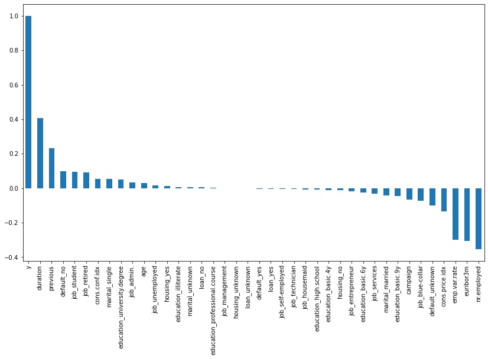

```python
#Bar Plot Korelasi Variabel y dengan semua variabel x

plt.figure(figsize=(14,8))
df4.corr()['y'].sort_values(ascending = False).plot(kind='bar')
```

## Preprocessing

```python
# Memisahkan variabel x dan variabel y

x = df4.drop('y',axis=1)
y = df4['y']
```

```python
# Normalisasi Data

sc = StandardScaler()
x_tr = sc.fit_transform(x)
```

Sebelum kita olah datanya terlebih dahulu kita harus melakukan normalisasi data. Normalisasi data ini diperlukan karena range antara atribut prediktor satu dengan yang lainnya cukup jauh maka kita gunakan normalisasi standard agar range antar variabel tersebut tidak terlalu jauh.

```python
#Cek Multikolinearitas

from statsmodels.stats.outliers_influence import variance_inflation_factor
vif = pd.DataFrame()
vif['vif'] = [variance_inflation_factor(x_tr,i) for i in range(x_tr.shape[1])]
vif['features'] = x.columns
vif
```

|  | vif | features |
| --- | --- | --- |
| 0 | 1.670301 | age |
| 1 | 1.009024 | duration |
| 2 | 1.039461 | campaign |
| 3 | 1.352695 | previous |
| 4 | 33.763058 | emp.var.rate |
| 5 | 6.447192 | cons.price.idx |
| 6 | 2.669334 | cons.conf.idx |
| 7 | 65.053198 | euribor3m |
| 8 | 31.825100 | nr.employed |
| 9 | 25.544365 | job_admin. |
| 10 | 23.445104 | job_blue-collar |
| 11 | 5.389943 | job_entrepreneur |
| 12 | 4.225013 | job_housemaid |
| 13 | 9.579121 | job_management |
| 14 | 6.295774 | job_retired |
| 15 | 5.307934 | job_self-employed |
| 16 | 12.312120 | job_services |
| 17 | 3.755675 | job_student |
| 18 | 18.937249 | job_technician |
| 19 | 4.087003 | job_unemployed |
| 20 | 2.589103 | marital_married |
| 21 | 2.901329 | marital_single |
| 22 | 1.020327 | marital_unknown |
| 23 | 3.310451 | education_basic.4y |
| 24 | 2.317528 | education_basic.6y |
| 25 | 4.112682 | education_basic.9y |
| 26 | 5.411734 | education_high.school |
| 27 | 1.011653 | education_illiterate |
| 28 | 3.966065 | education_professional.course |
| 29 | 6.351075 | education_university.degree |
| 30 | inf | default_no |
| 31 | inf | default_unknown |
| 32 | inf | default_yes |
| 33 | inf | housing_no |
| 34 | inf | housing_unknown |
| 35 | inf | housing_yes |
| 36 | inf | loan_no |
| 37 | inf | loan_unknown |
| 38 | inf | loan_yes |

karena terdapat beberapa variabel yang memiliki nilai VIF lebih dari 10, maka kita harus menghapus variabel tersebut agar tidak terdapat multikolinearitas

#### Mengulangi kembali proses multikolinearitas dengan mengahapus beberapa variabel yang memiliki nilai VIF lebih dari 10

```python
data=df4.drop(columns=['default_no', 'emp.var.rate', 'euribor3m', 'nr.employed', 'job_admin.', 'job_blue-collar', 'default_unknown', 'default_yes', 'housing_no', 'job_services', 'housing_unknown', 'job_technician', 'housing_yes', 'loan_no', 'loan_unknown', 'loan_yes'],axis=1)
data
```

|  | age | duration | campaign | previous | cons.price.idx | cons.conf.idx | job_entrepreneur | job_housemaid | job_management | job_retired | ... | marital_single | marital_unknown | education_basic.4y | education_basic.6y | education_basic.9y | education_high.school | education_illiterate | education_professional.course | education_university.degree | y |
| --- | --- | --- | --- | --- | --- | --- | --- | --- | --- | --- | --- | --- | --- | --- | --- | --- | --- | --- | --- | --- | --- |
| 0 | 56 | 261 | 1 | 0 | 93.994 | -36.4 | 0 | 1 | 0 | 0 | ... | 0 | 0 | 1 | 0 | 0 | 0 | 0 | 0 | 0 | 0 |
| 1 | 57 | 149 | 1 | 0 | 93.994 | -36.4 | 0 | 0 | 0 | 0 | ... | 0 | 0 | 0 | 0 | 0 | 1 | 0 | 0 | 0 | 0 |
| 2 | 37 | 226 | 1 | 0 | 93.994 | -36.4 | 0 | 0 | 0 | 0 | ... | 0 | 0 | 0 | 0 | 0 | 1 | 0 | 0 | 0 | 0 |
| 3 | 40 | 151 | 1 | 0 | 93.994 | -36.4 | 0 | 0 | 0 | 0 | ... | 0 | 0 | 0 | 1 | 0 | 0 | 0 | 0 | 0 | 0 |
| 4 | 56 | 307 | 1 | 0 | 93.994 | -36.4 | 0 | 0 | 0 | 0 | ... | 0 | 0 | 0 | 0 | 0 | 1 | 0 | 0 | 0 | 0 |
| ... | ... | ... | ... | ... | ... | ... | ... | ... | ... | ... | ... | ... | ... | ... | ... | ... | ... | ... | ... | ... | ... |
| 41183 | 73 | 334 | 1 | 0 | 94.767 | -50.8 | 0 | 0 | 0 | 1 | ... | 0 | 0 | 0 | 0 | 0 | 0 | 0 | 1 | 0 | 1 |
| 41184 | 46 | 383 | 1 | 0 | 94.767 | -50.8 | 0 | 0 | 0 | 0 | ... | 0 | 0 | 0 | 0 | 0 | 0 | 0 | 1 | 0 | 0 |
| 41185 | 56 | 189 | 2 | 0 | 94.767 | -50.8 | 0 | 0 | 0 | 1 | ... | 0 | 0 | 0 | 0 | 0 | 0 | 0 | 0 | 1 | 0 |
| 41186 | 44 | 442 | 1 | 0 | 94.767 | -50.8 | 0 | 0 | 0 | 0 | ... | 0 | 0 | 0 | 0 | 0 | 0 | 0 | 1 | 0 | 1 |
| 41187 | 74 | 239 | 3 | 1 | 94.767 | -50.8 | 0 | 0 | 0 | 1 | ... | 0 | 0 | 0 | 0 | 0 | 0 | 0 | 1 | 0 | 0 |

41188 rows × 24 columns

```python
# Memisahkan variabel x dan variabel y

x = data.drop('y',axis=1)
y = data['y']
```

```python
# Normalisasi Data

sc = StandardScaler()
x_tr = sc.fit_transform(x)
```

```python
#Cek Multikolinearitas

vif = pd.DataFrame()
vif['vif'] = [variance_inflation_factor(x_tr,i) for i in range(x_tr.shape[1])]
vif['features'] = x.columns
vif
```

|  | vif | features |
| --- | --- | --- |
| 0 | 1.630524 | age |
| 1 | 1.006671 | duration |
| 2 | 1.026399 | campaign |
| 3 | 1.065760 | previous |
| 4 | 1.080170 | cons.price.idx |
| 5 | 1.048993 | cons.conf.idx |
| 6 | 1.025562 | job_entrepreneur |
| 7 | 1.056137 | job_housemaid |
| 8 | 1.112783 | job_management |
| 9 | 1.303576 | job_retired |
| 10 | 1.028480 | job_self-employed |
| 11 | 1.107550 | job_student |
| 12 | 1.009719 | job_unemployed |
| 13 | 2.573024 | marital_married |
| 14 | 2.888741 | marital_single |
| 15 | 1.017113 | marital_unknown |
| 16 | 3.165116 | education_basic.4y |
| 17 | 2.239759 | education_basic.6y |
| 18 | 3.939340 | education_basic.9y |
| 19 | 5.121611 | education_high.school |
| 20 | 1.010996 | education_illiterate |
| 21 | 3.600464 | education_professional.course |
| 22 | 5.895929 | education_university.degree |

Karena nilai VIF kurang dari 10 semuanya. Maka sudah tidak terdapat lagi multikolinearitas

## Model

```python
x_train,x_test,y_train,y_test=train_test_split(x_tr,y,test_size=0.2,random_state=123,stratify=y)
```

Membagi data dengan train test split sebesar 80% data train dan 20% data test

### Logistic Regression

```python
from sklearn.linear_model import LogisticRegression
from sklearn.metrics import accuracy_score,confusion_matrix,classification_report
lr = LogisticRegression(penalty='l2',C=0.1)
lr.fit(x_train,y_train)

y_test_pred = lr.predict(x_test)
y_train_pred = lr.predict(x_train)

lr_acc=accuracy_score(y_test_pred,y_test)

print("Train Set Accuracy:"+str(accuracy_score(y_train_pred,y_train)*100))
print("Test Set Accuracy:"+str(accuracy_score(y_test_pred,y_test)*100))
print("\nConfusion Matrix:\n%s"%confusion_matrix(y_test_pred,y_test))
print("\nClassification Report:\n%s"%classification_report(y_test_pred,y_test))
```

```
Train Set Accuracy:89.74506828528072
Test Set Accuracy:89.48773974265598

Confusion Matrix:
[[7140  696]
 [ 170  232]]

Classification Report:
              precision    recall  f1-score   support

           0       0.98      0.91      0.94      7836
           1       0.25      0.58      0.35       402

    accuracy                           0.89      8238
   macro avg       0.61      0.74      0.65      8238
weighted avg       0.94      0.89      0.91      8238
```

Dari metode logistic regression didapatkan nilai antara precision, recall, f1-score tidak seimbang yang berarti model tersebut sangat tidak baik dalam memprediksi suatu tuple sehingga ada ketimpangan antar label yaitu pada label 0 dan 1 terpaut sangat jauh untuk precision dan f1-score dan akurasi yang didapatkan sebesar 89%.

#### Penghitungan Secara Manual

**Label 0**

- TP = 7140
- TN = 232
- FN = 170
- FP = 696
- Accuracy = (TP+TN)/(TP+FP+TN+FN) = 0.895
- Precision = TP/(TP+FP) = 0.91
- Recall/Sensitivity = TP/(TP+FN) = 0.977
- Specificity = TN/(TN+FP) = 0.25
- F1-Score = 2 Recall Precision / (Recall + Precision) = 0.94

**Label 1**

- TP = 232
- TN = 7140
- FN = 696
- FP = 170
- Accuracy = (TP+TN)/(TP+FP+TN+FN) = 0.895
- Precision = TP/(TP+FP) = 0.577
- Recall/Sensitivity = TP/(TP+FN) = 0.25
- Specificity = TN/(TN+FP) = 0.977
- F1-Score = 2 Recall Precision / (Recall + Precision) = 0.35

### Naive Bayes

```python
gnb = GaussianNB()
gnb.fit(x_train,y_train)

y_test_pred2 = gnb.predict(x_test)
y_train_pred2=gnb.predict(x_train)

print("Train Set Accuracy:"+str(accuracy_score(y_train_pred2,y_train)*100))
print("Test Set Accuracy:"+str(accuracy_score(y_test_pred2,y_test)*100))
print("\nConfusion Matrix:\n%s"%confusion_matrix(y_test_pred2,y_test))
print("\nClassification Report:\n%s"%classification_report(y_test_pred2,y_test))
```

```
Train Set Accuracy:85.98482549317147
Test Set Accuracy:85.48191308570041

Confusion Matrix:
[[6624  510]
 [ 686  418]]

Classification Report:
              precision    recall  f1-score   support

           0       0.91      0.93      0.92      7134
           1       0.45      0.38      0.41      1104

    accuracy                           0.85      8238
   macro avg       0.68      0.65      0.66      8238
weighted avg       0.85      0.85      0.85      8238
```

Dari metode naive bayes didapatkan nilai antara precision, recall, f1-score tidak seimbang yang berarti model tersebut tidak baik dalam memprediksi suatu tuple sehingga ada ketimpangan antar label yaitu pada label 0 dan 1 terpaut jauh untuk precision dan f1-score dan akurasi yang didapatkan sebesar 85%.

#### Penghitungan Secara Manual

**Label 0**

- TP = 6624
- TN = 418
- FN = 686
- FP = 510
- Accuracy = (TP+TN)/(TP+FP+TN+FN) = 0.86
- Precision = TP/(TP+FP) = 0.93
- Recall/Sensitivity = TP/(TP+FN) = 0.91
- Specificity = TN/(TN+FP) = 0.45
- F1-Score = 2 Recall Precision / (Recall + Precision) = 0.92

**Label 1**

- TP = 418
- TN = 6624
- FN = 510
- FP = 686
- Accuracy = (TP+TN)/(TP+FP+TN+FN) = 0.86
- Precision = TP/(TP+FP) = 0.38
- Recall/Sensitivity = TP/(TP+FN) = 0.45
- Specificity = TN/(TN+FP) = 0.91
- F1-Score = 2 Recall Precision / (Recall + Precision) = 0.41

### Decision Tree

```python
dtc = DecisionTreeClassifier()
dtc.fit(x_train, y_train)

y_test_pred3 = dtc.predict(x_test)
y_train_pred3=dtc.predict(x_train)


print("Train Set Accuracy:"+str(accuracy_score(y_train_pred3,y_train)*100))
print("Test Set Accuracy:"+str(accuracy_score(y_test_pred3,y_test)*100))
print("\nConfusion Matrix:\n%s"%confusion_matrix(y_test_pred3,y_test))
print("\nClassification Report:\n%s"%classification_report(y_test_pred3,y_test))
```

```
Train Set Accuracy:99.99393019726858
Test Set Accuracy:88.86865744112649

Confusion Matrix:
[[6840  447]
 [ 470  481]]

Classification Report:
              precision    recall  f1-score   support

           0       0.94      0.94      0.94      7287
           1       0.52      0.51      0.51       951

    accuracy                           0.89      8238
   macro avg       0.73      0.72      0.72      8238
weighted avg       0.89      0.89      0.89      8238
```

Dari metode decision tree didapatkan nilai antara precision, recall, f1-score kurang seimbang yang berarti model tersebut cenderung kurang baik dalam memprediksi suatu tuple sehingga ada ketimpangan antar label yaitu pada label 0 dan 1 terpaut cukup jauh untuk precision dan f1-score dan akurasi yang didapatkan sebesar 89%.

**Label 0**

**Label 1**

## Interpretasi

### Klasifikasi

**Logistic Regression** : Model tersebut sangat tidak baik dalam memprediksi suatu tuple dan akurasi yang didapatkan sebesar 89%.

**Naive Bayes** : Model tersebut tidak baik dalam memprediksi suatu tuple dan akurasi yang didapatkan sebesar 85%.

### Confusion matrix

**Accuracy** : Rasio subjek yang diidentifikasi dengan benar dalam kumpulan subjek.

Logistic Regression : 0.895

Naive Bayes : 0.86

Decision Tree : 0.89

**Precision** : Rasio subjek yang diidentifikasi dengan benar +ve berdasarkan pengujian, terhadap semua subjek +ve yang diidentifikasi berdasarkan pengujian.

Logistic Regression : Label 1 (0.91) dan Label 2 (0.577)

Naive Bayes : Label 1 (0.93) dan Label 2 (0.38)

**Recall/Sensitivity** : Rasio subjek yang diidentifikasi dengan benar +ve dengan tes terhadap semua subjek +ve dalam kenyataan.

Logistic Regression : Label 1 (0.977) dan Label 2 (0.25)

Naive Bayes : Label 1 (0.91) dan Label 2 (0.45)

Decision Tree : Label 1 (0.94) dan Label 2 (0.51)

**Specificity** : Rasio subjek yang diidentifikasi dengan benar dengan tes terhadap semua subjek -ve dalam kenyataan.

Logistic Regression : Label 1 (0.25) dan Label 2 (0.977)

Naive Bayes : Label 1 (0.45) dan Label 2 (0.91)

Decision Tree : Label 1 (0.51) dan Label 2 (0.94)

**F1 SCORE** : Skor F1 menyumbang presisi dan sensitivitas.

Logistic Regression : Label 1 (0.94) dan Label 2 (0.35)

Naive Bayes : Label 1 (0.92) dan Label 2 (0.41)

Decision Tree : Label 1 (0.94) dan Label 2 (0.51)

### Kesimpulan

Kesimpulan yang di dapatkan adalah ketiga metode yang di pakai belum cukup baik untuk dapat memprediksikan data yang ada, meskipun akurasi yang didapatkan dari ketiga metode tersebut sangat bagus. Oleh karena itu diperlukan metode lain atau di perlukan penanganan data yang lebih lanjut agar data menjadi lebih baik lagi sehingga metode yang di coba dapat melakukan prediksi.